# Group 02 - Skin Cancer

Leonie Thomas, Isabel Potthof, Elif Tosun and Marlene Khin

24.07.2019

# **First step: Setting the sys-path and loading the data**

```r
root.dir = dirname(rstudioapi::getSourceEditorContext()$path)
data = readRDS(paste0(root.dir, "/DepMap19Q1_allData.RDS"))
```

# **1. Data cleanup**

- Extracting the cell lines of the skin cancer.
- Creating a new dataframe which only contains the data we will work with.

```r
sample_case = c("Skin Cancer")
```

- Searching only for the primary disease Skin Cancer in the annotation matrix.

```r
samples = data$annotation$DepMap_ID[which(data$annotation$Primary.Disease == sample_case)]
```

- A vector containing all the cell lines with skin cancer as the primary disease is obtained.
- –> 34 cell lines have the primary disease skin cancer.
- Extracting all cell lines defined in the previous step out of the data (except the mutation matrix).

```r
processed_data <- lapply(1:length(dt_new), function(a) { # picking the data for our sample
  dat_picker <- dt_new[[a]] # picking one file at each iteration
  if(names(dt_new[a])== "annotation"){ # treating the annotations differnetly because the cell line names are in a colum and are not the columnames like in the other matrices
    output <- dat_picker[which(dat_picker[,1] %in% samples),]
  } else {
  output <- dat_picker[,which(colnames(dat_picker) %in% samples)]# only taking the skin cancer cell lines
  output <- output[complete.cases(output),] # only taking rows without NAs
  output <- output[order(rownames(output)),] # reordering the genes according to their name
  }
  return(output)
})
names(processed_data) <- names(dt_new) # renameing the objects according to the original data
rm(dt_new,sample_case) # removing objects which are not need anymore
```

- Extracting the skin cancer cell lines out of the mutation matrix.
- Losing the mutations which are not deleterious meaning not interesting to us.
- Using a if iteration with the condition to just extract the genes which are in every data frame.
- Putting all data back together in one object.
- Looking at the processed data.

```
##         ACH-000014 ACH-000274 ACH-000304 ACH-000322 ACH-000348
## A1BG    6.08661395 0.79908731 5.21179100 5.24716800 5.67694436
## A1CF    0.05658353 0.08406426 0.01435529 0.04264434 0.00000000
## A2M     6.14425036 7.95006009 6.83605000 6.00360224 4.62993941
## A2ML1   0.23878686 0.01435529 0.00000000 0.00000000 0.01435529
## A4GALT  0.97819563 0.02856915 0.12432810 0.98550043 3.09592442
## A4GNT   0.07038933 0.11103131 0.00000000 0.04264434 0.09761080
## AAAS    5.97613447 5.61087720 5.55642900 5.72737594 5.85424505
## AACS    5.13463167 5.08788710 4.21645500 4.14241344 4.17552460
## AADAC   0.01435529 0.21412481 0.05658353 0.07038933 0.33342373
## AADACL2 0.02856915 0.00000000 0.00000000 0.00000000 0.02856915
```

```
##         ACH-000014 ACH-000274 ACH-000304 ACH-000322 ACH-000348
## A1BG        0.0989  -0.097469     0.0184     0.0536     0.2243
## A1CF       -0.3120   0.005770    -0.9286    -0.3620    -0.2004
## A2M         0.1110   0.014809     0.0080     0.0876    -0.1028
## A2ML1       0.1110   0.014809     0.0080     0.1893    -0.1028
## A4GALT      0.0580  -0.011931     0.0359     0.2368    -0.1255
## A4GNT       0.0961  -0.001092     0.0207     0.4689     0.2784
## AAAS        0.1107   0.014809     0.0115    -0.0250    -0.1559
## AACS        0.1120   0.014809     0.0340     0.0906    -0.1817
## AADAC       0.0768   0.015465     0.0304     0.4689     0.2784
## AADACL2     0.0768   0.015465     0.0304     0.4689     0.2784
```

```
##          ACH-000014  ACH-000274   ACH-000304  ACH-000322  ACH-000348
## A1BG     0.11297899  0.09000078  0.123999117  0.17552003  0.05979116
## A1CF    -0.03533250  0.13896177  0.274438862  0.08205882  0.07506780
## A2M      0.02880611 -0.07116082 -0.201401893  0.01866713 -0.05790399
## A2ML1    0.16933390  0.10695957  0.291635816  0.20971252  0.09614451
## A4GALT  -0.08469817 -0.11183837 -0.164706825  0.07185597 -0.05414073
## A4GNT   -0.11754729  0.03983944 -0.005448509 -0.01545300  0.07601372
## AAAS    -0.37103349 -0.41828686 -0.195925758 -0.28411957 -0.32252314
## AACS    -0.04540626  0.02847436 -0.097559375 -0.08118755 -0.01892812
## AADAC    0.13828797  0.16723110  0.147066204  0.38636762  0.04059718
## AADACL2  0.07158946  0.08736997  0.084883216  0.23972258  0.09690599
```

```
##          ACH-000014  ACH-000274  ACH-000304   ACH-000322  ACH-000348
## A1BG    0.002774072 0.004409101 0.002713543 9.701586e-04 0.006625887
## A1CF    0.023529328 0.002004631 0.000372957 4.262132e-03 0.005132902
## A2M     0.009873198 0.039221771 0.103075053 1.047207e-02 0.037397252
## A2ML1   0.001095265 0.003375634 0.000306326 5.420935e-04 0.003550176
## A4GALT  0.042860321 0.061256566 0.075245128 4.955556e-03 0.035654746
## A4GNT   0.061754873 0.009330674 0.014367402 1.639439e-02 0.005049978
## AAAS    0.417853626 0.491584887 0.098458357 2.246814e-01 0.386247431
## AACS    0.026723760 0.010955990 0.039643561 3.609931e-02 0.022159161
## AADAC   0.001837255 0.001242681 0.001980259 1.917526e-05 0.009061951
## AADACL2 0.005275945 0.004588671 0.004600816 3.200669e-04 0.003501290
```

```
##      DepMap_ID     CCLE_Name                Aliases Primary.Disease
## 13  ACH-000014   HS294T_SKIN Hs 294T;A101D;Hs 294.T     Skin Cancer
## 269 ACH-000274   HS852T_SKIN               Hs 852.T     Skin Cancer
## 299 ACH-000304    WM115_SKIN                 WM-115     Skin Cancer
## 317 ACH-000322    HT144_SKIN                 HT-144     Skin Cancer
## 343 ACH-000348 RPMI7951_SKIN              RPMI-7951     Skin Cancer
## 393 ACH-000401  COLO800_SKIN               COLO-800     Skin Cancer
## 396 ACH-000404   K029AX_SKIN                 K029AX     Skin Cancer
## 418 ACH-000425   UACC62_SKIN                UACC-62     Skin Cancer
## 443 ACH-000450    MELHO_SKIN                 MEL-HO     Skin Cancer
## 451 ACH-000458      CJM_SKIN                    CJM     Skin Cancer
##     Subtype.Disease
## 13         Melanoma
## 269        Melanoma
## 299        Melanoma
## 317        Melanoma
## 343        Melanoma
## 393        Melanoma
## 396        Melanoma
## 418        Melanoma
## 443        Melanoma
## 451        Melanoma
```

# **2. Visualizing our data**

- Converting all data in a format which is useable for or plotting package.
- Extracting the data we need for plotting out of the mutation matrix.

## **2.1 Heatmap with the the kd.ceres matrix (knock down data)**

- Random sample of first 50 genes.
- To get an overview if the genes influence cell proliferation.

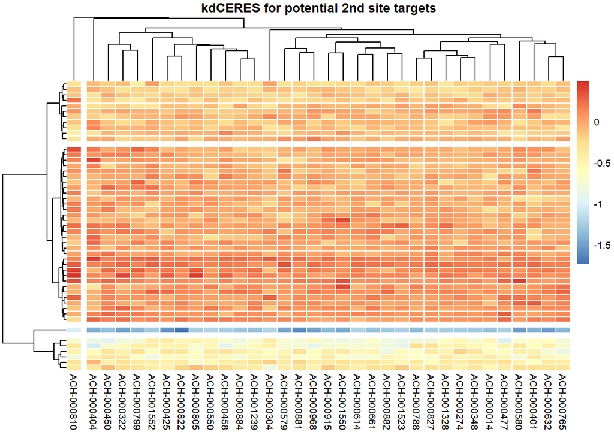

```r
pheatmap(as.matrix(processed_data$kd.ceres[1:50,]), clustering_method = "ward.D2",border_color = "white", fontsize = 8,
         main = paste0("kdCERES for potential 2nd site targets"),
         show_rownames = F, show_colnames = T,
         cutree_rows = 4,
         cutree_cols = 2,
         fontsize_row=8)
```

> - *Some genes lead to a higher, some to a lower value.*
> - *–>Further investigation which genes play a role in cell proliferation and could be involved in cancer development.*

## **2.2 Distribution of the expression values between the different cell lines**

- Creating a boxplot with the expression matrix.
- To see how the expression of the genes is distributed over the different cell lines.

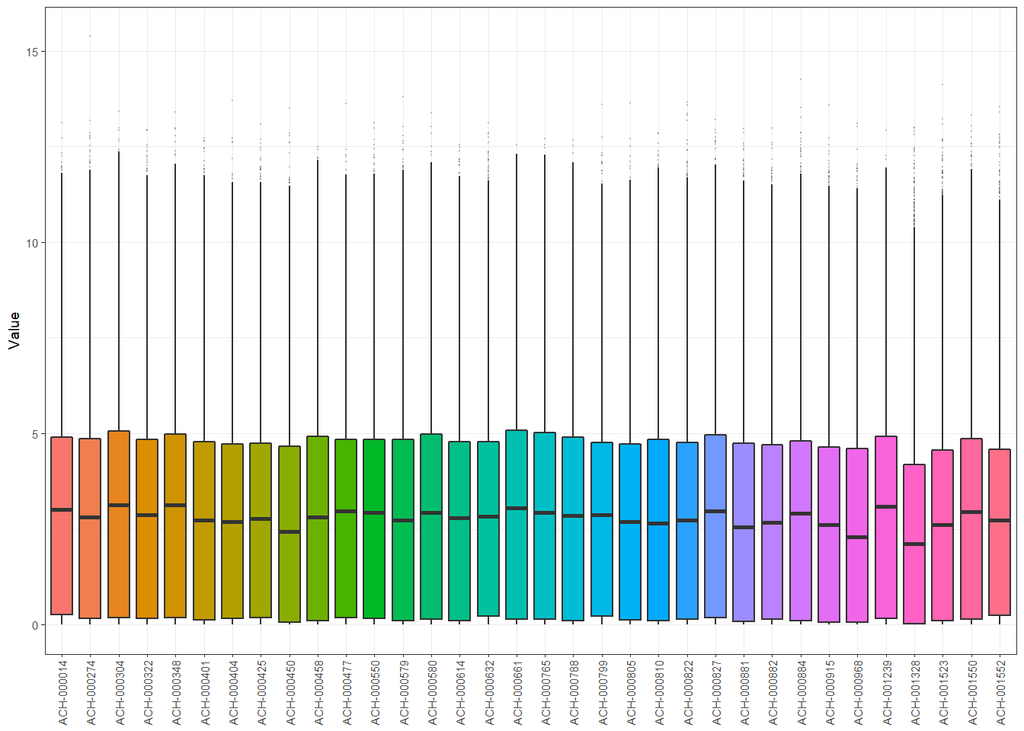

> - *Many genes are distributed between the 25 and 75 quantile.*
> - *There are also some outliers which are of special interest in the following data analysis.*

## **2.3 Top 10 mutated genes**

- Creating a barplot to see which genes are most often mutated.
- These genes were characterized when extracting the useable information out of the mutation matrix.

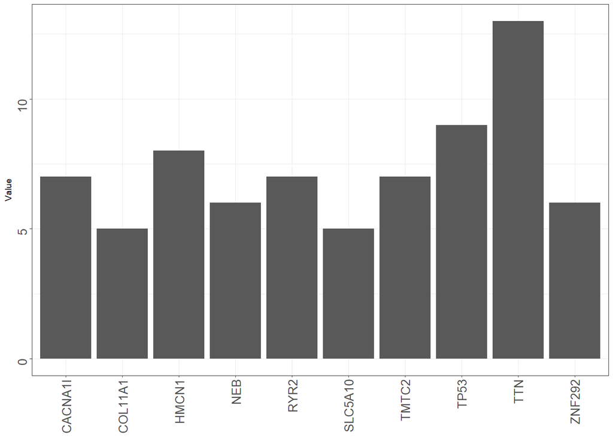

# **3. Dimensionality reduction**

## **3.1 Hierachical clustering**

Creating a hierachical cluster with our driver mutations.

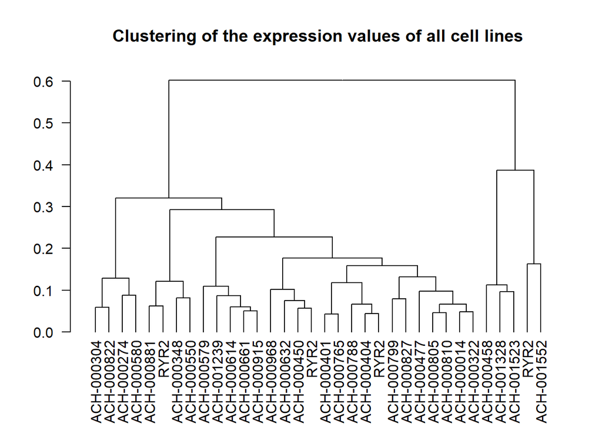

> - We hoped that the driver mutations cluster together, but they don`t.
> - Because most of the timer there is more than one driver mutation in every cell line.

## **3.2 K-means**

- Performing a k-means.
- Using the kink method to identify the best number of clusters.

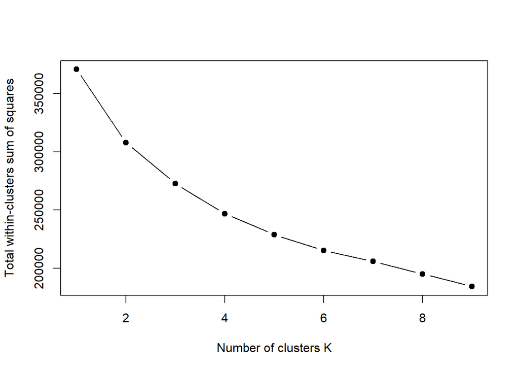

- Now we try the silouette method.

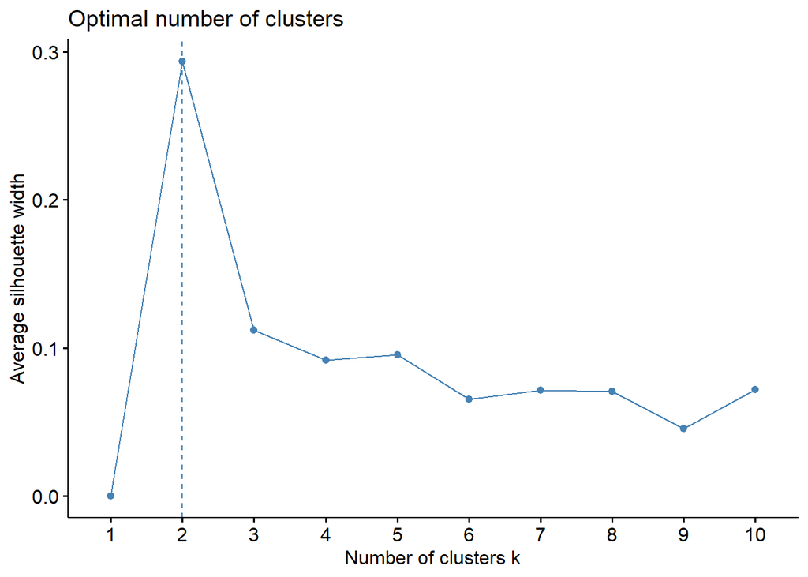

```r
fviz_nbclust(dataset, kmeans, method = "silhouette")
```

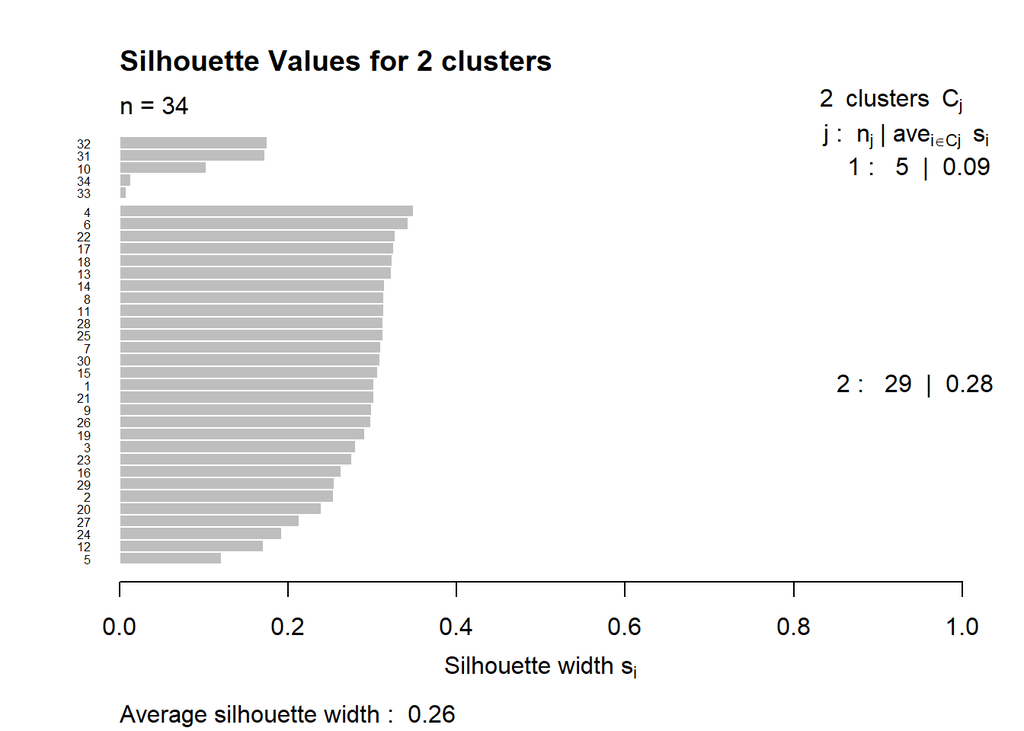

```r
# according to the silhouette method the clustering with two centers seems to be the best one

# taking a look at the clustering with different centers (2, 4, 5, 10)
km = kmeans(x =dataset, centers = 2, nstart = 100)
plot(silhouette(km$cluster,dist(dataset)), main = "Silhouette Values for 2 clusters", cex=0.5)
```

```r
# taking a look at the clustering with different centers (2, 4, 5, 10)
km2 <- kmeans(dataset, centers = 2, nstart = 100)
km3 <- kmeans(dataset, centers = 5, nstart = 100)
km4 <- kmeans(dataset, centers = 4, nstart = 100)
km5 <- kmeans(dataset, centers = 10, nstart = 100)
```

- Two clusters seem to be the best.
- But we want to take a look at different clusters.

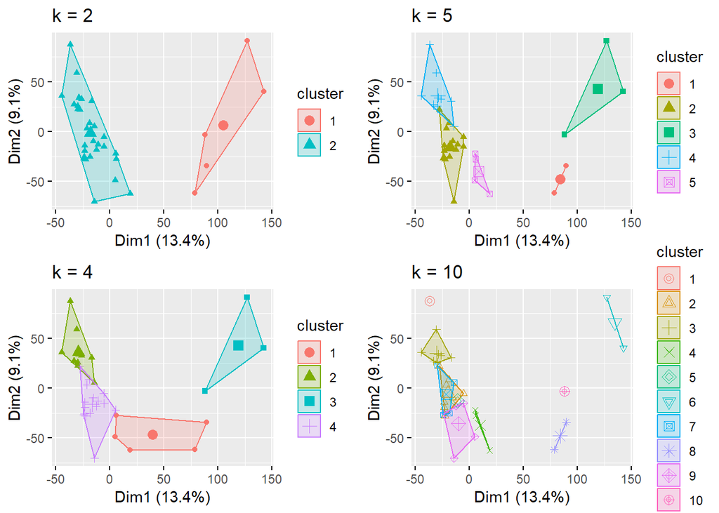

[figure not shown]

[figure not shown]

```r
p1 <- fviz_cluster(km2,geom = "point", data = dataset) + ggtitle("k = 2")
p2 <- fviz_cluster(km3, geom = "point", data = dataset) + ggtitle("k = 5")
p3 <- fviz_cluster(km4, geom = "point", data = dataset) + ggtitle("k = 4")
p4 <- fviz_cluster(km5, geom = "point", data = dataset) + ggtitle("k = 10")

grid.arrange(p1, p2, p3, p4, nrow = 2)
```

> - *The clustering with two centers seems to be the best one.*
> - *Our next step in the pca will be to see which of the genes drive the differentiation of the celllines in this plot because they will be the most variable and thus most interesting ones.*

# **3.3 PCA**

- Performing a pca investigate what drives the difference in the clustering.

```r
dataset <- processed_data$expression # determining which dataset will be used
colnames(dataset)<- cellinesMutations$Genes # sets the labels to the Drivermutaion every Cell lines

pca = prcomp(t(dataset), center = F, scale. = F)
summary(pca)
```

```
## Importance of components:
##                             PC1      PC2      PC3      PC4      PC5
## Standard deviation     495.3869 46.27533 35.11722 26.07913 24.64502
## Proportion of Variance   0.9573  0.00835  0.00481  0.00265  0.00237
## Cumulative Proportion    0.9573  0.96567  0.97048  0.97313  0.97550
##                             PC6      PC7      PC8      PC9     PC10
## Standard deviation     21.01126 20.73196 19.77350 19.31929 17.76823
## Proportion of Variance  0.00172  0.00168  0.00153  0.00146  0.00123
## Cumulative Proportion   0.97723  0.97890  0.98043  0.98188  0.98312
##                            PC11    PC12     PC13     PC14     PC15
## Standard deviation     17.71421 16.8245 16.18356 15.71160 15.43367
## Proportion of Variance  0.00122  0.0011  0.00102  0.00096  0.00093
## Cumulative Proportion   0.98434  0.9854  0.98647  0.98743  0.98836
##                            PC16     PC17     PC18     PC19     PC20
## Standard deviation     15.26658 14.96113 14.46341 13.90066 13.62804
## Proportion of Variance  0.00091  0.00087  0.00082  0.00075  0.00072
## Cumulative Proportion   0.98927  0.99014  0.99096  0.99171  0.99243
##                            PC21     PC22     PC23     PC24     PC25
## Standard deviation     13.48726 13.20117 13.08648 12.66417 12.34321
## Proportion of Variance  0.00071  0.00068  0.00067  0.00063  0.00059
## Cumulative Proportion   0.99314  0.99382  0.99449  0.99512  0.99571
##                            PC26     PC27     PC28     PC29     PC30
## Standard deviation     11.96792 11.74491 11.66818 11.40272 11.21416
## Proportion of Variance  0.00056  0.00054  0.00053  0.00051  0.00049
## Cumulative Proportion   0.99627  0.99681  0.99734  0.99785  0.99834
##                            PC31     PC32     PC33    PC34
## Standard deviation     10.83176 10.65546 10.26134 9.49512
## Proportion of Variance  0.00046  0.00044  0.00041 0.00035
## Cumulative Proportion   0.99879  0.99924  0.99965 1.00000
```

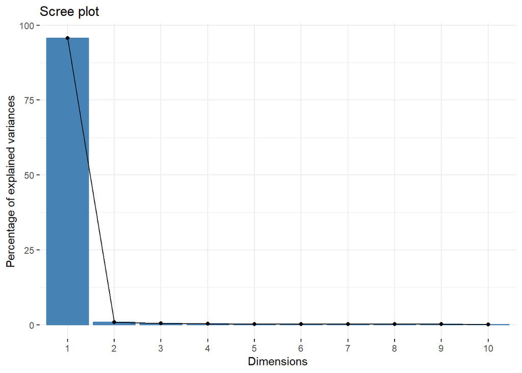

```r
fviz_eig(pca)
```

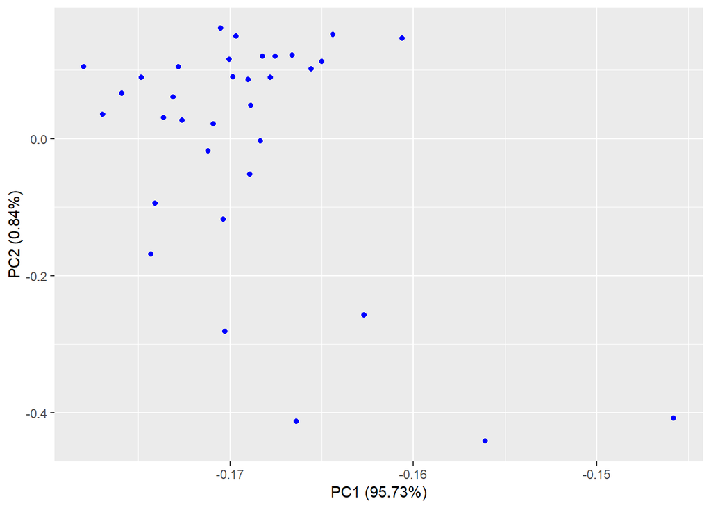

[figure not shown]

```r
autoplot(pca, colour = 'blue')
```

> - *Again we see two clusters.*
> - *The first principal component contains the most information about the data.*

```
##                 PC1          PC2          PC3          PC4
## A1BG   8.458140e-03 4.042140e-02 2.820464e-03 1.626858e-03
## A1CF   1.017925e-07 9.118405e-08 6.046034e-06 1.241073e-05
## A2M    6.063349e-03 4.405875e-02 8.758703e-02 1.918378e-02
## A2ML1  2.113426e-06 8.293155e-04 5.108695e-04 6.804066e-04
## A4GALT 5.277506e-04 5.244157e-02 2.770271e-03 6.278979e-03
## A4GNT  3.632784e-06 1.020123e-08 5.599425e-05 1.554282e-05
```

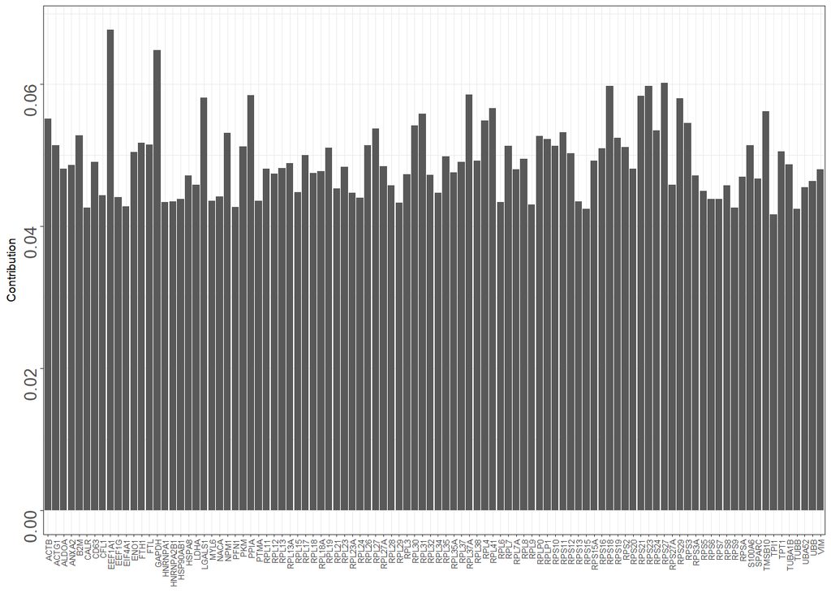

```r
top100var.contrib <- var.contrib[,1]
top100var.contrib <- as.data.frame(top100var.contrib[order(-top100var.contrib)])
top100var.contrib$Genes <- rownames(top100var.contrib)
top100var.contrib <- top100var.contrib[1:100,]
colnames(top100var.contrib)[1] <- "Contribution"
```

> - *These are the components which are contributing the most to our variation in the data. Maybe we will find some of these in our result of the p-test.*

# **4. Statistical test**

Aim : Identify combinations of one driver gene with one other gene which are strongly correlated.

Data: Knockdown Data

Procedure:

1. Design a vector which contains the names of the 10 driver mutations.
2. Design a 2nd vector which contains the names of all the genes in our data.
3. Design an iteration with the lapply function which calculates the p-value of every combination of the elemtents of these two vectors.
4. We will select combination of genes with the lowest p-value.

**Hypothesis: We can find gene combinations with low p-values which indicates a high correlation.**

```r
driverGenes <- rownames(geneCounts)[1:10] # only using the TOP 10 driver genes
ttestgenes <- rownames(processed_data$kd.ceres)

potSecondSites <- lapply(seq_along(driverGenes), function(a) {
  genePicker <- driverGenes[a] # picking one driver gene
  output <- sapply(seq_along(rownames(processed_data$kd.ceres)), function(b) {
    secondSitePicker <- rownames(processed_data$kd.ceres)[b] # picking a potetnial 2nd site target
    if (secondSitePicker != genePicker) {
      drMUT <- processed_data$kd.ceres[which(rownames(processed_data$kd.ceres) == genePicker),] # picking the mutation data
      sndMUT <- as.vector(processed_data$kd.ceres[which(rownames(processed_data$kd.ceres) == secondSitePicker),]) # picking the 2nd site data
      cor.val <- cor.test(unlist(drMUT, use.names=FALSE) , unlist(sndMUT, use.names=FALSE), method = "spearman") # making a spearman correlation
      return(cor.val$p.value) # returning the p-values
    } else {
      return(1)
    }
  })
  names(output) <- rownames(processed_data$kd.ceres) # renaming all
  output <- as.data.frame(output) # getting a nice data frame
  return(output)
})
names(potSecondSites) <- driverGenes # renaming the list of lists
```

```
## $TTN
##                         V1       V2
## 1619  0.000192182904986292 C18orf21
## 9311  0.000216211877859173     NFIC
## 14283 0.000216211877859173   TADA2A
## 1308  0.000305219955221227     BDH1
## 14708 0.000368698310471896    TLCD1
## 15183 0.000387934595388336      TPO
##
## $TP53
##                         V1     V2
## 2499                     0 CDKN1A
## 11816 0.000103223370174727  RAD50
## 14298 0.000108353027416951   TAF4
## 14764   0.0001137107198288  TMCC1
## 4371  0.000125145813836725   ELP5
## 2900  0.000126344262370283 CLNS1A
##
## $HMCN1
##                         V1      V2
## 3855  0.000158378567481514   DLEC1
## 7868  0.000169002222357213     LPA
## 14241 0.000253909255393287    SYT1
## 2696  0.000279735414494879  CHI3L2
## 1086  0.000289692104459778 ATP13A4
## 15195 0.000335624844619134   TPRX1
##
## $TMTC2
##                         V1       V2
## 6823   0.00010123343332492    INPP1
## 6415  0.000105248422076675   HPCAL4
## 6838  0.000128772111611712    INSL4
## 10807 0.000155455177571188     PIM1
## 1630  0.000156910773724267 C19orf44
## 13439 0.000183596672063156   SLC6A5
##
## $RYR2
##                         V1      V2
## 5170  0.000115919614615094     FOS
## 10974 0.000132492432119933  PLSCR1
```

[output cut: 34 more lines]

```
## 3713  0.000228181021531897 DEFB108B
## 5233  0.000240738465474526      FRK
## 10256 0.000299963530168467      OXT
## 16705 0.000318721898691953   ZNF560
## 2882  0.000329903893887125    CLIC6
## 9029  0.000329903893887125    MYOM1
##
## $SLC5A10
##                         V1        V2
## 8177  0.000103223370174727    MAP2K4
## 13850 0.000131241747909797     SPNS2
## 16525 0.000234384661247794    ZNF256
## 6648  0.000242890314341453     IFT52
## 13815 0.000272469365943009     SPEM1
## 7249  0.000289692104459778 KIAA1324L
```

Example for one driver mutation:

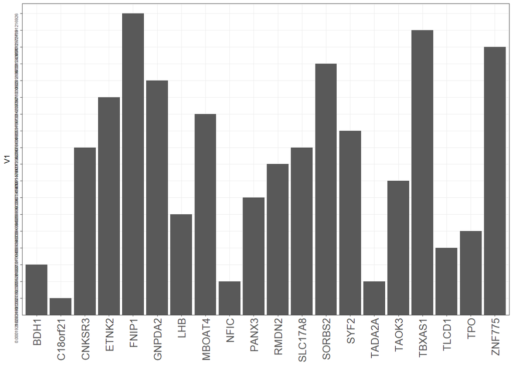

> Identified Combinations seem most likely to have a functional relationship/interaction with the driver mutations. Verification of this hypotheses with more data.

# **5. Multiple linear regression analysis**

## **5.1 Predicting the expression of our driver genes with all the data**

1. create a Dataframe with all the data

This should look like this:

```
##       Sample   Gene      Value copynumber    kd.ceres     kd.prob
## 1 ACH-000014   A1BG 6.08661395     0.0989  0.11297899 0.002774072
## 2 ACH-000014   A1CF 0.05658353    -0.3120 -0.03533250 0.023529328
## 3 ACH-000014    A2M 6.14425036     0.1110  0.02880611 0.009873198
## 4 ACH-000014  A2ML1 0.23878686     0.1110  0.16933390 0.001095265
## 5 ACH-000014 A4GALT 0.97819563     0.0580 -0.08469817 0.042860321
## 6 ACH-000014  A4GNT 0.07038933     0.0961 -0.11754729 0.061754873
##   Driverexpression
## 1        0.5058909
## 2        0.5058909
## 3        0.5058909
## 4        0.5058909
## 5        0.5058909
## 6        0.5058909
```

```r
a <- generalPlottingData$expression[,1:3]
a <-a[,c(1,3,2)]
copynumber <- generalPlottingData$copynumber[,2]
kd.ceres <- generalPlottingData$kd.ceres[,2]
kd.prob <- generalPlottingData$kd.prob[,2]

RegData <- cbind(a,copynumber,kd.ceres,kd.prob)

Regressionanalysis <-lapply(1:10, function(x){
  RegData <- cbind(a,copynumber,kd.ceres,kd.prob)
  Driverexpression <- c()
  for (i in 1:34) { # 34 = te skin cancer cell lines
    a <- 16970*i # 16970 = number of genes
    c <- (16970* (i-1))+1
    b <- colnames(processed_data$expression)[i]
    Driverexpression[c:a] <- processed_data$expression[rownames(geneCounts)[x],b]
  }
  RegData <- cbind(RegData,Driverexpression)
  RegData <-as.data.frame(RegData)
  colnames(RegData) <- as.vector(colnames(RegData))
  set.seed(123) # initializing the random numbers
  split = sample.split(RegData, SplitRatio = 0.8) # splitting the dataset into 4/5 Training and 1/5 Testing dataset
  training_set = subset(RegData, split == TRUE) # using the labels to get the training data
  test_set = subset(RegData, split == FALSE)
  rm(RegData)
  # fitting the multiple linear regression to the Training set
  regressor = lm( Driverexpression ~  copynumber + Value + kd.ceres + kd.prob , data = training_set)
  # predicting the test set results
  y_pred = predict(regressor, newdata = test_set, se.fit = TRUE) # predicting the expression based on the testing data
  test_set$Prediction = y_pred$fit # adding the predictions to the dataset
  Results <- cor.test(test_set$Driverexpression, test_set$Prediction, method = "spearman", exact=FALSE)
  return(Results)
})
names(Regressionanalysis) <- rownames(geneCounts)[1:10]
Regressionanalysis <- as.vector(Regressionanalysis)
```

```
##    DriverGene       pvalue       Svalue
## 1         TTN 5.509211e-16 7.317806e+14
## 2        TP53 4.997652e-09 7.359220e+14
## 3       HMCN1 5.739113e-37 7.233205e+14
## 4       TMTC2 1.486016e-36 7.234577e+14
## 5        RYR2 1.671884e-30 7.255677e+14
## 6     CACNA1I 7.949257e-20 7.299161e+14
## 7      ZNF292 9.481412e-12 7.341441e+14
## 8         NEB 5.286592e-14 7.328378e+14
## 9     COL11A1 1.548789e-77 7.124150e+14
## 10    SLC5A10 4.727922e-25 7.276653e+14
```

> - *Our Model is able to reproduce and predict the expression values of our driver genes.*
> - *Using the top 20 out of the statistical testing we hope to verify our thesis that these Genes are most important for the drivergene expression.* ***

```r
print(ResultsRegressiontop20)
```

```
##    DriverGene     pvalue      Svalue
## 1         TTN 0.09746992 49026556057
## 2        TP53 0.04382470 49238451647
## 3       HMCN1 0.88944564 48128985972
## 4       TMTC2 0.12381370 48956640123
## 5        RYR2 0.10252586 49012065541
## 6     CACNA1I 0.42022190 48523361801
## 7      ZNF292 0.07410218 49102647128
## 8         NEB 0.79788512 48198209845
## 9     COL11A1 0.80113984 48195718948
## 10    SLC5A10 0.20397571 48797830898
```

> - *This result of the Regression analysis do not confirm our thesis.*

# **6.Results**

> Using the data of the PC1 to confirm our thesis.

```r
Resultspresentation <- lapply(1:length(potSecondSitestop20), function(x){
  return(potSecondSitestop20[[x]][2])
})

names(Resultspresentation) <- rownames(geneCounts)[1:10]
print(Resultspresentation)
```

```
## $TTN
##             V2
## 1619  C18orf21
## 9311      NFIC
## 14283   TADA2A
## 1308      BDH1
## 14708    TLCD1
## 15183      TPO
## 7750       LHB
## 10332    PANX3
## 14321    TAOK3
## 12208    RMDN2
## 2967    CNKSR3
## 13171  SLC17A8
## 14213     SYF2
```

[output cut: 214 more lines]

```r
print(top100var.contrib[1:20,2])
```

```
##  [1] "EEF1A1" "GAPDH"  "RPS27"  "RPS23"  "RPS18"  "RPL37A" "PPIA"
##  [8] "RPS21"  "LGALS1" "RPS29"  "RPL41"  "TMSB10" "RPL31"  "ACTB"
## [15] "RPL4"   "RPS3"   "RPL30"  "RPL27"  "RPS24"  "RPS11"
```

```r
which(top100var.contrib[1:20,2] %in% as.character(melt(Resultspresentation)[,1]))
```

```
## integer(0)
```

# **6.Results**

**Driver mutation and second targets**

| TTN | TP53 |
| --- | --- |
| C18orf21 | CDNK1A |
| NFIC | RAD50 |
| TADA2A | TAF4 |

> In which context are our driver mutations to be put in and how do they interact with their second targets ?

## TTN

*largest protein in human genome also known as connectin*

- Location: sacromere in steriated muscle
- Function: connects the Z line to the M line in the sacromere â> contration of cardiac and skeletal muscle
- Related Disease: dilated cardiomyopathy
- Predicted second targets: C18orf21, NFIC, TADA2A

> C18orf21:chromosome 18 open reading frame 21  
> NFIC: cellular transcription factors  
> TADA2A: DNA-binding transcriptional activator proteins

# Network of TTN and second targets

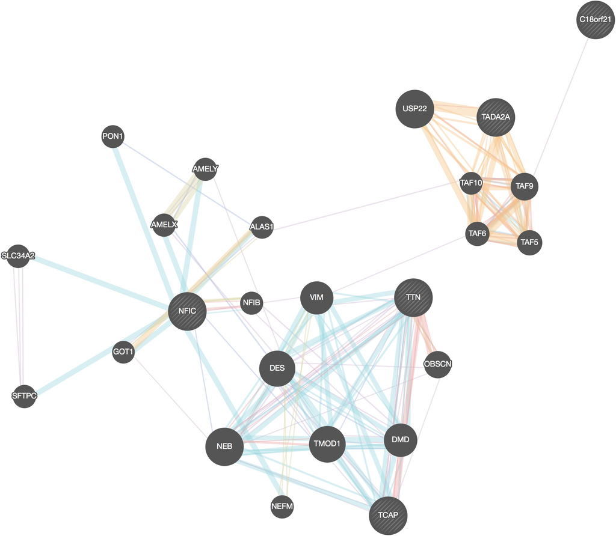

- > no direct link between driver mutation and second targets can be identified

## TP53

*tumor suppresor protein*

- Location: RNA expression in all tissues

# Protein expression of TP53

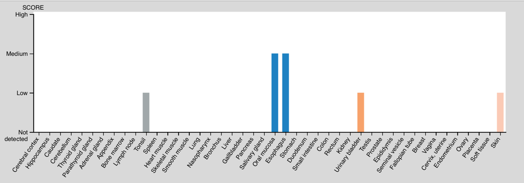

*protein expression of TP53 in human tissue (3,4)*

- Function: regulation of cell cycle, apoptosis and genomic stabilty
- Related Disease: general Cancer-related genes

## TP53 and skin cancer

- TP53 is an UVR target
- UVR-induced TP53 mutations accelerates BRAF-driven melanomagenesis

Comparison of TP53 expression

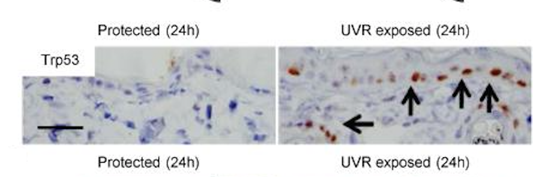

*arrows point at stained tissue with increased TP53 expression (10)*

> possible second targets of TP53 could be intresting target point for skin cancer theraphy
- Predicted second targets: CDKN1A, RAD50, TAF4

# Network of TP53 and second targets

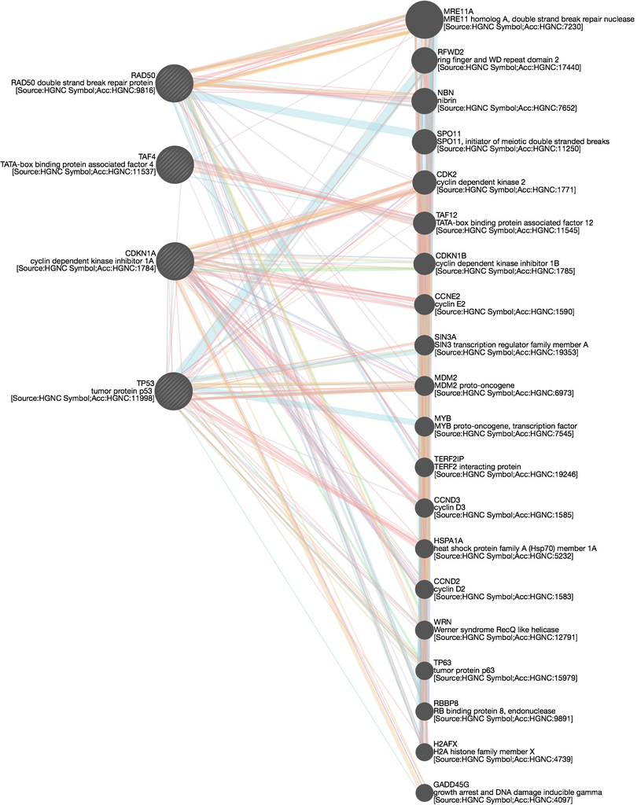

*Network is generated by GeneMANIA is shown above*

> pathway of TP53 and CDKN1A are connected.

# Network of pathways between TP53 and CDKN1A

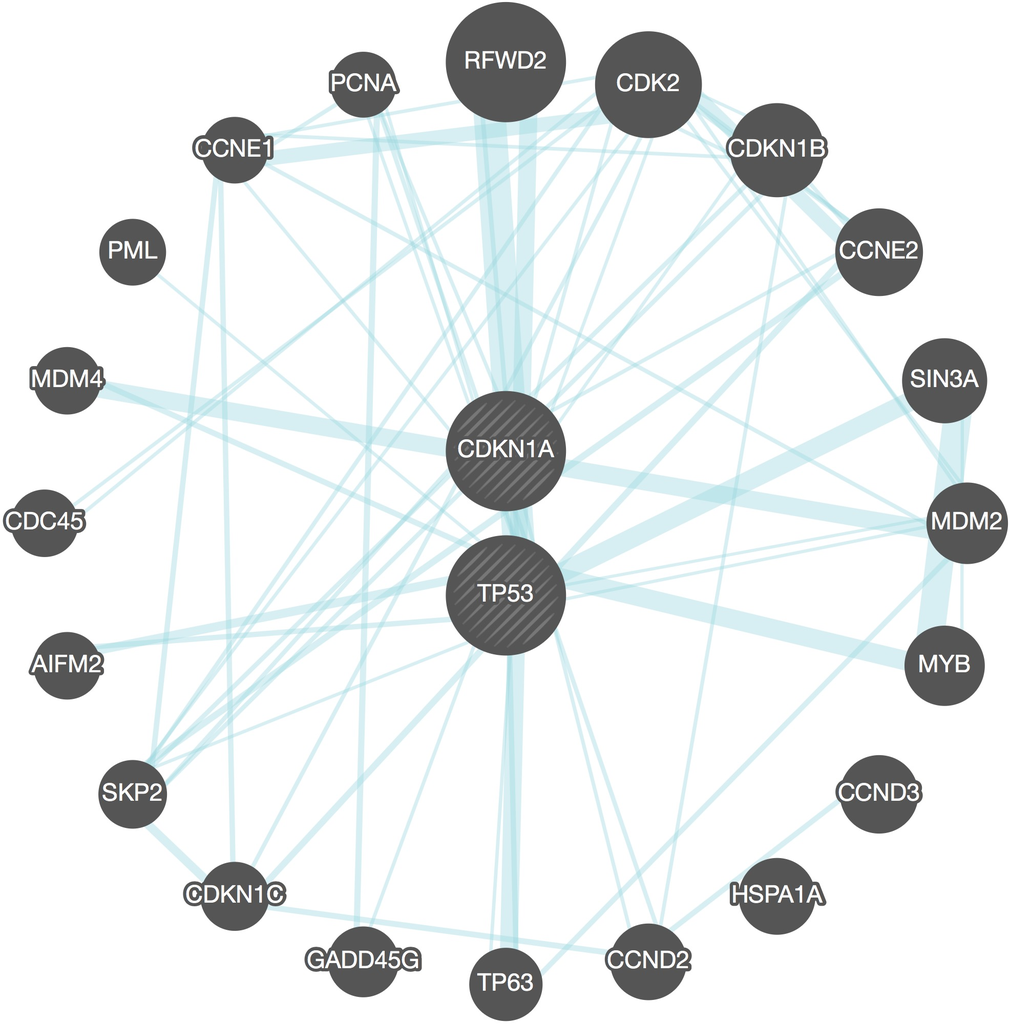

*pathways conecting TP53 and CDKN1A generated by GeneMANIA are shown above*

expression of CDKN1A is controlled by TP53, â> mediates the p53-dependent cell cycle G1 phase arrest

## Conclusion

- Our mathematical model was successfully able to predict the interaction between TP53 and and the second target CDKN1A
- CDKN1A could be a possible sencond target in skin cancer therapy

References (1) Akbani et al. (2015), Genomic Classification of Cutaneous Melanoma. Cell 161, 1681-1696  
(2) Gigli M, Begay RL, Morea G, et al. A Review of the Giant Protein Titin in Clinical Molecular Diagnostics of Cardiomyopathies. Front Cardiovasc Med. 2016;3:21. Published 2016 Jul 21. doi:10.3389/fcvm.2016.00021  
(3) Uhlén M et al, 2015. Tissue-based map of the human proteome. Science PubMed: 25613900 DOI: 10.1126/science.1260419, Human Protein Atlas  
(4) Warde-Farley D, Donaldson SL, Comes O, Zuberi K, Badrawi R, Chao P, Franz M, Grouios C, Kazi F, Lopes CT, Maitland A, Mostafavi S, Montojo J, Shao Q, Wright G, Bader GD, Morris Q Nucleic Acids Res. 2010 Jul 1;38 Suppl:W214-20 PubMed Abstract  
(5) Clancy T, Rødland EA, Nygard S, Hovig E. Predicting physical interactions between protein complexes. Mol Cell Proteomics. 2013;12(6):1723-1734. doi:10.1074/ mcp.O112.019828  
(6) Pruitt KD, Tatusova T, Brown GR, Maglott DR. NCBI Reference Sequences (RefSeq): current status, new features and genome annotation policy. Nucleic Acids Res. 2012;40(Database issue):D130-D135. doi:10.1093/nar/gkr1079  
(7) O’Leary NA, Wright MW, Brister JR, Ciufo S, Haddad D, McVeigh R, Rajput B, Robbertse B, Smith-White B, Ako-Adjei D, Astashyn A, Badretdin A, Bao Y, Blinkova O, Brover V, Chetvernin V, Choi J, Cox E, Ermolaeva O, Farrell CM, Goldfarb T, Gupta T, Haft D, Hatcher E, Hlavina W, Joardar VS, Kodali VK, Li W, Maglott D, Masterson P, McGarvey KM, Murphy MR, O’Neill K, Pujar S, Rangwala SH, Rausch D, Riddick LD, Schoch C, Shkeda A, Storz SS, Sun H, Thibaud-Nissen F, Tolstoy I, Tully RE, Vatsan AR, Wallin C, Webb D, Wu W, Landrum MJ, Kimchi A, Tatusova T, DiCuccio M, Kitts P, Murphy TD, Pruitt KD. Reference sequence (RefSeq) database at NCBI: current status, taxonomic expansion, and functional annotation. Nucleic Acids Res. 2016 Jan 4;44(D1):D733-45 PubMed Tatusova T, DiCuccio M, Badretdin A, Chetvernin V, Nawrocki EP, Zaslavsky L, Lomsadze A, Pruitt KD, Borodovsky M, Ostell J. NCBI prokaryotic genome annotation pipeline. Nucleic Acids Res. 2016 Aug 19;44(14):6614-24 PubMed Brister JR, Ako-Adjei D, Bao Y, Blinkova O. NCBI viral genomes resource. Nucleic Acids Res. 2015 Jan;43(Database issue):D571-7 PubMed  
(8) Benjamin CL, Ananthaswamy HN. p53 and the pathogenesis of skin cancer. Toxicol Appl Pharmacol. 2007;224(3):241-248. doi:10.1016/j.taap.2006.12.006  
(9) Soto JL, Cabrera CM, Serrano S, López-Nevot MA. Mutation analysis of genes that control the G1/S cell cycle in melanoma: TP53, CDKN1A, CDKN2A, and CDKN2B. BMC Cancer. 2005;5:36. Published 2005 Apr 8. doi:10.1186/1471-2407-5-36 (10) Viros A, Sanchez-Laorden B, Pedersen M, et al. Ultraviolet radiation accelerates BRAF-driven melanomagenesis by targeting TP53. Nature. 2014;511(7510):478â“482. doi:10.1038/nature13298